# Lab 5

Author

Hannah Pawig

# Revisiting Lab 2

**Click me to see the code!**

```r
library(tidyverse)
library(here)
library(forcats)
library(lubridate)
options(dplyr.summarise.inform = FALSE)
```

**Click me to see the code!**

```r
surveys <- read_csv(here::here("supporting_artifacts",
                              "learning_targets",
                              "Lab 5",
                              "surveys.csv"))
```

**Click me to see the code!**

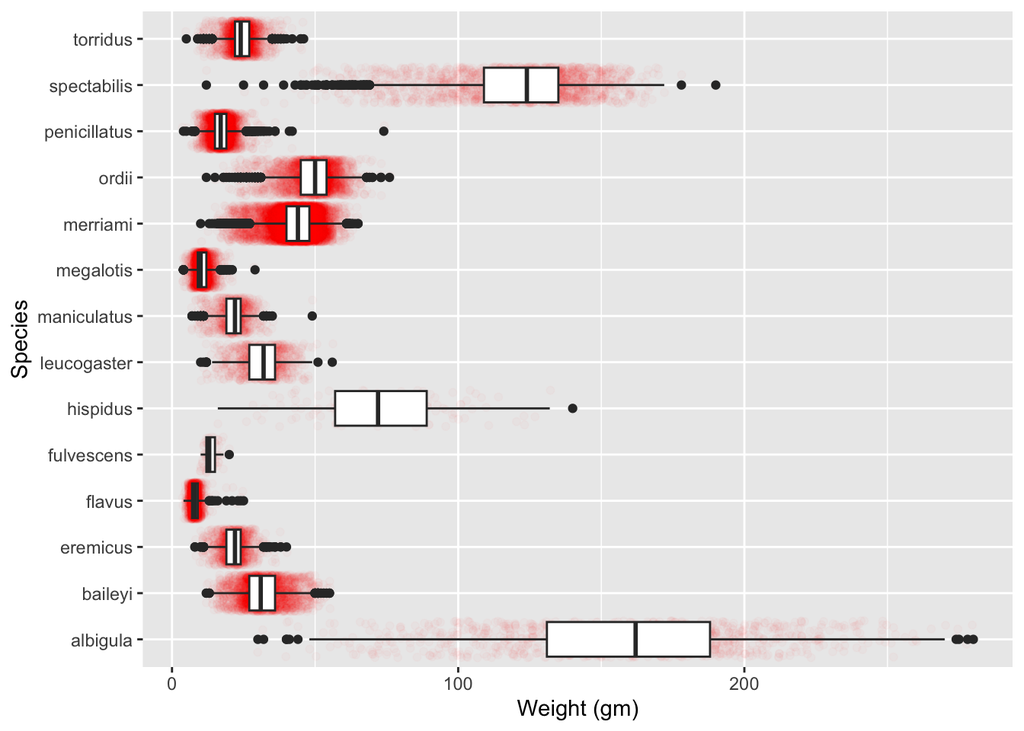

```r
surveys |>
  ggplot(mapping = aes(x = weight, y = species)) +
        geom_jitter(alpha = 0.02, color = "red") +
        geom_boxplot() +
        xlab("Weight (gm)") +
        ylab("Species")
```

1. Reordering the box-plots to descending order &
2. Moving the y-axis label to the top.

**Click me to see the code!**

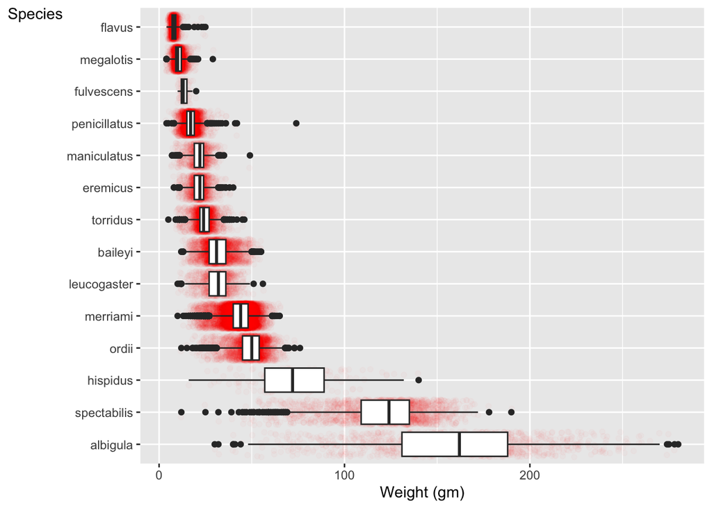

```r
# resource: https://stackoverflow.com/questions/1330989/rotating-and-spacing-axis-labels-in-ggplot2
surveys |>
  mutate(
    species = as.factor(species),
    species = fct_reorder(.f = species,
                          .x = weight,
                          .desc = TRUE)) |>
  ggplot(mapping = aes(x = weight, y = species)) +
        geom_jitter(alpha = 0.02, color = "red") +
        geom_boxplot() +
        xlab("Weight (gm)") +
        ylab("Species") +
  theme(axis.title.y = element_text(angle = 0))
```

# Time-Series Plot

3. Visualization of weights varying in each genus across time in the study.

**Click me to see the code!**

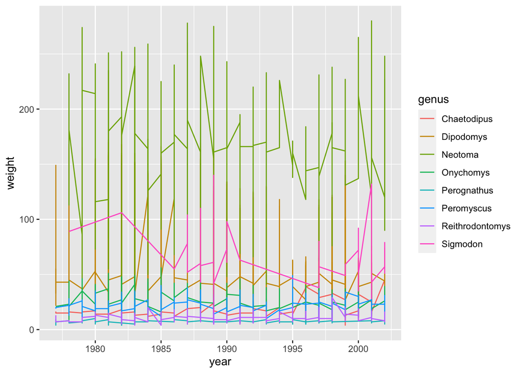

```r
surveys |>
  ggplot(mapping = aes(x = year,
                       y = weight,
                       color = genus)) +
  geom_line()
```

4. Calculate and plot the mean weight for each year (for each genus).

**Click me to see the code!**

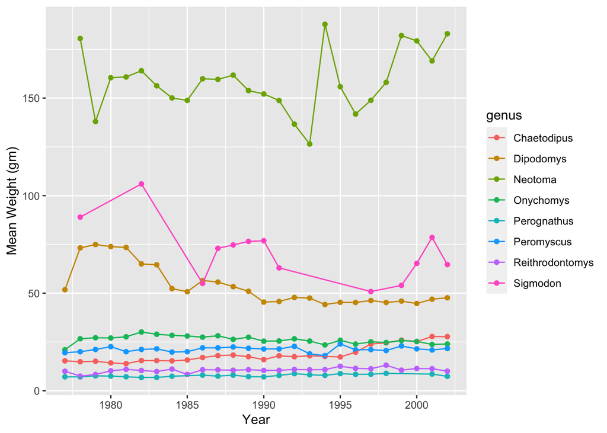

```r
surveys |>
  group_by(genus, year) |>
  summarise(mean_weight = mean(weight)) |>
  ggplot(mapping = aes(x = year,
                       y = mean_weight,
                       color = genus)) +
  geom_point() +
  geom_line() +
  labs(x = "Year",
       y = "Mean Weight (gm)")
```

5. Reorder the graph so the weights go in descending order.

**Click me to see the code!**

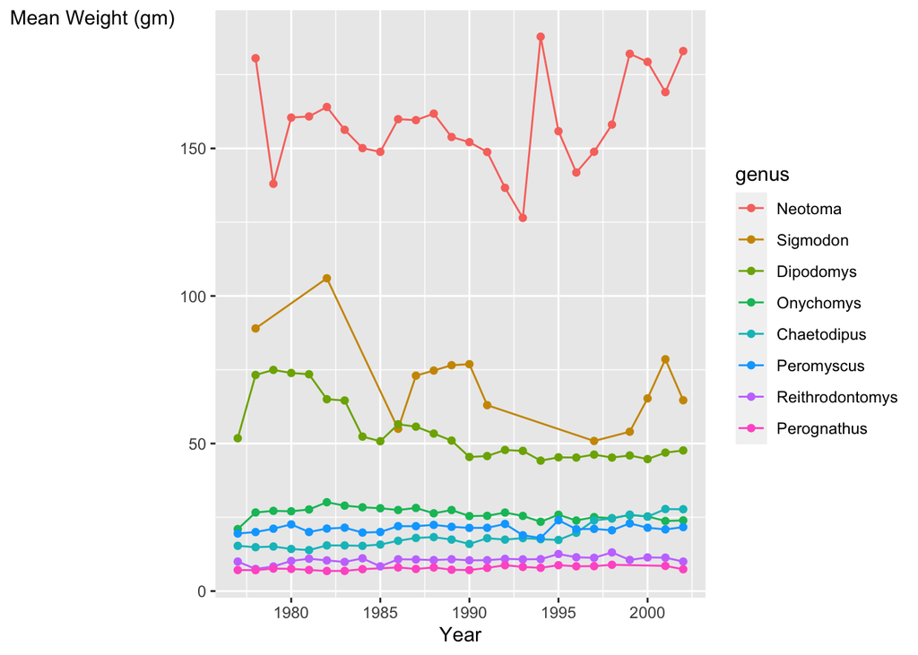

```r
# resource for legend reordering
# https://stackoverflow.com/questions/10074483/r-how-to-reorder-legend-key-in-ggplot2-line-plot-to-match-the-final-values-in-e
#| message: false
surveys |>
  mutate(
    genus = as.factor(genus),
    genus = fct_reorder(.f = genus,
                        .x = weight,
                        .desc = TRUE)) |>
  group_by(year, genus) |>
  summarize(mean_weight = mean(weight)) |>
  ggplot(mapping = aes(x = year,
                       y = mean_weight,
                       color = genus)) +
  labs(x = "Year",
       y = "Mean Weight (gm)") +
  geom_line() +
  geom_point() +
  theme(axis.title.y = element_text(angle = 0))
```

6. New legend title and moving y-axis information to the plot title

**Click me to see the code!**

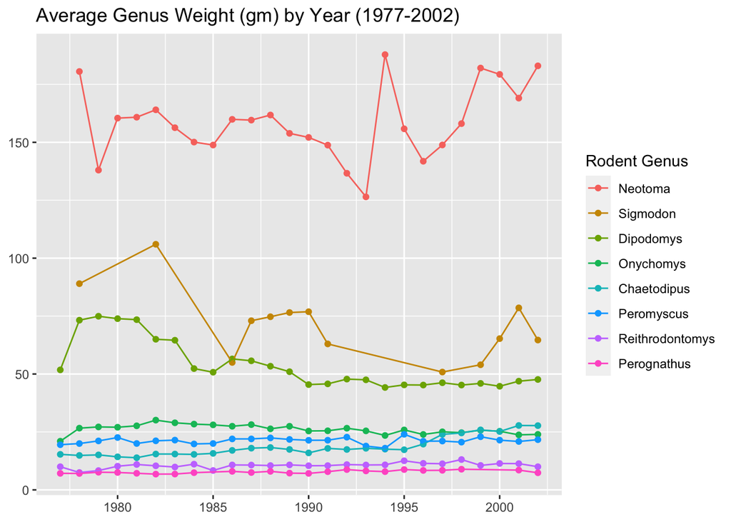

```r
surveys |>
  mutate(
    genus = as.factor(genus),
    genus = fct_reorder(.f = genus,
                        .x = weight,
                        .desc = TRUE)) |>
  group_by(year, genus) |>
  summarise(mean_weight = mean(weight)) |>
  ggplot(mapping = aes(x = year,
                       y = mean_weight,
                       color = genus)) +
  geom_point() +
  geom_line() +
  labs(x = "Year",
       color = "Rodent Genus",
       title = "Average Genus Weight (gm) by Year (1977-2002)") +

    theme(axis.title.y = element_blank(),
        axis.title.x = element_blank())
```

# Captures over the Week

7. Create a visualization of the number of rodents captured each day of the week

**Click me to see the code!**

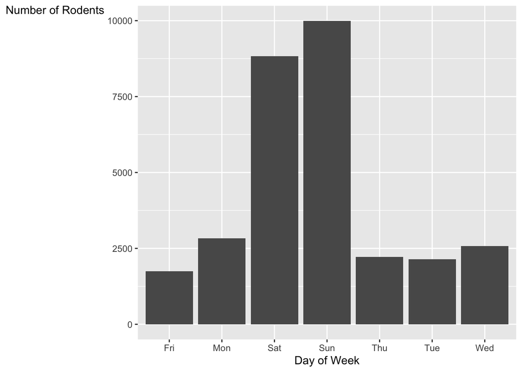

```r
surveys |>
  filter(!is.na(day_of_week)) |> #removed observations with NA for day of week
  ggplot(mapping = aes(x = day_of_week)) +
  geom_bar() +
  labs(x = "Day of Week",
       y = "Number of Rodents") +
  theme(axis.title.y = element_text(angle = 0))
```

8. Change the order of the day of the week to go Monday through Sunday.

**Click me to see the code!**

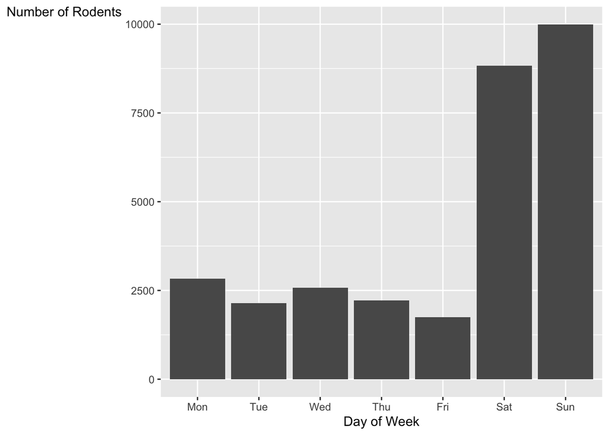

```r
surveys_plot_data <- surveys |>
  filter(!is.na(day_of_week)) |>
  mutate(
    day_of_week =
    fct_relevel(day_of_week, c("Mon", "Tue", "Wed", "Thu", "Fri", "Sat", "Sun")))

surveys_plot_data |>
  ggplot(mapping = aes(x = day_of_week)) +
  geom_bar() +
  labs(x = "Day of Week",
       y = "Number of Rodents") +
  theme(axis.title.y = element_text(angle = 0))
```

9. Collapse Mon-Fri into a `Weekday` level, and collapse Saturday and Sunday into a `Weekend` level. Plot the number of rodents captured between the two groups.

**Click me to see the code!**

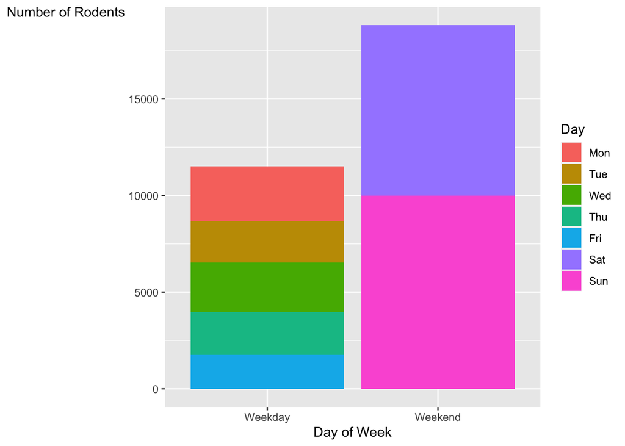

```r
surveys_plot_data |>
  mutate(day_type = fct_collapse(day_of_week,
                                Weekday = c("Mon", "Tue", "Wed",
                                            "Thu", "Fri"),
                                Weekend = c("Sat", "Sun"))) |>
  ggplot(mapping = aes(x = day_type,
                       fill = day_of_week)) +
  geom_bar() +
  labs(x = "Day of Week",
       y = "Number of Rodents",
       fill = "Day") +
  theme(axis.title.y = element_text(angle = 0))
```